# Election Forecast 2022

Alina Vikhnevich

2025-02-02

## Introduction

In this analysis, we aim to clean, transform, and visualize the dataset to better understand election trends. By exploring seat projections and vote margin fluctuations, we can observe how public opinion shifted leading up to the election. —

## Data Visualization

The following plots visualize key election trends:

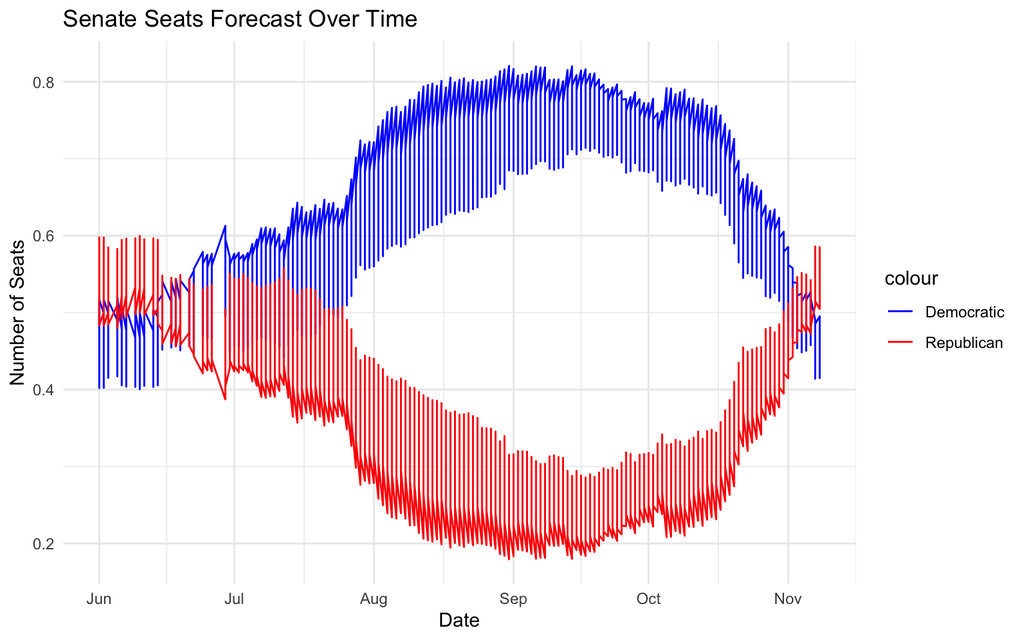

```r
ggplot(election_df, aes(x=Date)) +
  geom_line(aes(y=Democratic_Seats, color="Democratic")) +
  geom_line(aes(y=Republican_Seats, color="Republican")) +
  theme_minimal() +
  labs(
    title="Senate Seats Forecast Over Time",
    x="Date",
    y="Number of Seats"
  ) +
  scale_color_manual(values = c("Democratic" = "blue", "Republican" = "red"))
```

The second plot illustrates how the predicted popular vote margin fluctuated throughout the election period.

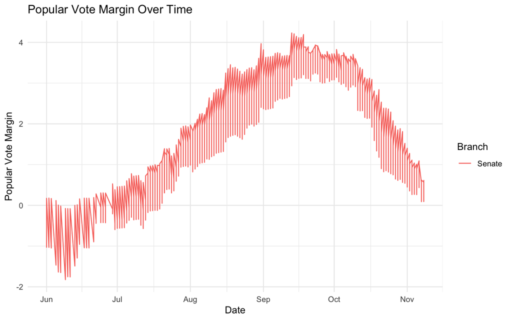

## Conclusion

Analyzing the 2022 FiveThirtyEight Election Forecast dataset provided meaningful insights into election trends. By examining seat forecasts and popular vote margins, we observed how public sentiment shifted over time.

The visualizations highlight how election projections evolved leading up to voting day, demonstrating the impact of polling trends and external influences.

This project was a great opportunity to work with real-world election data, offering a deeper understanding of how predictive models inform political analysis.